# Perspectives on Computational Modeling: Problem Set #7

Xingyun Wu

2017/2/26

## Part 1: Sexy Joe Biden (redux)

1. The mean squared error for the linear regression model using the training set is 395.2702.

```
##
## Call:
## lm(formula = biden ~ age + female + dem + rep + educ, data = bidenData)
##
## Residuals:
##     Min      1Q  Median      3Q     Max
## -75.546 -11.295   1.018  12.776  53.977
##
## Coefficients:
##              Estimate Std. Error t value Pr(>|t|)
## (Intercept)  58.81126    3.12444  18.823  < 2e-16 ***
## age           0.04826    0.02825   1.708   0.0877 .
## female        4.10323    0.94823   4.327 1.59e-05 ***
## dem          15.42426    1.06803  14.442  < 2e-16 ***
## rep         -15.84951    1.31136 -12.086  < 2e-16 ***
## educ         -0.34533    0.19478  -1.773   0.0764 .
## ---
## Signif. codes:  0 '***' 0.001 '**' 0.01 '*' 0.05 '.' 0.1 ' ' 1
##
## Residual standard error: 19.91 on 1801 degrees of freedom
## Multiple R-squared:  0.2815, Adjusted R-squared:  0.2795
## F-statistic: 141.1 on 5 and 1801 DF,  p-value: < 2.2e-16
```

```
## [1] 395.2702
```

2. The test MSE fo the model using the validation set approach: 399.8303. Compared to the training MSE with the entire dataset, the test MSE is a little bit higher. This means the model fits the training data better, but on the other hand produces more errors when fitting the testing data.

```
##
## Call:
## lm(formula = biden ~ age + female + dem + rep + educ, data = biden_split$train)
##
## Residuals:
##     Min      1Q  Median      3Q     Max
## -75.759 -10.736   0.903  12.930  53.675
##
## Coefficients:
##              Estimate Std. Error t value Pr(>|t|)
## (Intercept)  57.33735    3.69768  15.506  < 2e-16 ***
## age           0.03728    0.03362   1.109 0.267701
## female        4.17215    1.12671   3.703 0.000222 ***
## dem          16.32775    1.27664  12.790  < 2e-16 ***
## rep         -14.60704    1.55800  -9.375  < 2e-16 ***
## educ         -0.26017    0.23221  -1.120 0.262750
## ---
## Signif. codes:  0 '***' 0.001 '**' 0.01 '*' 0.05 '.' 0.1 ' ' 1
##
## Residual standard error: 19.89 on 1259 degrees of freedom
## Multiple R-squared:  0.2787, Adjusted R-squared:  0.2758
## F-statistic: 97.28 on 5 and 1259 DF,  p-value: < 2.2e-16
```

```
## [1] 399.8303
```

3. After repeating the validation set approach 100 times, I found the test MSEs are not stable. According to the histogram generated with the 100 test MSEs, they could be widely spread. And everytime I rerun the validation set approach, the distribution of the test MSEs are not exactly the same.

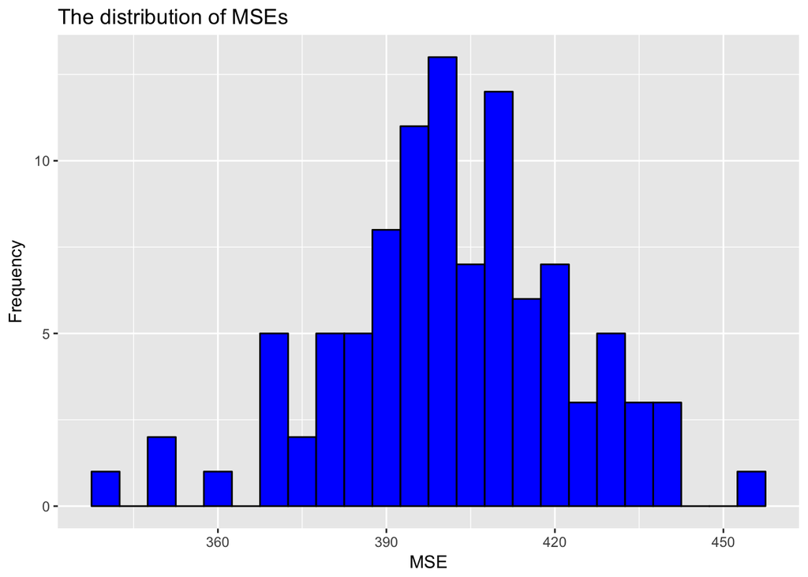

```
## [1] 401.6489
```

4. Using the leave-one-out cross-validation (LOOCV) approach, the test MSE is 397.9555. It is close to, but in many times of my running this approach smaller than the test MSEs estimated by the validation set approach. This means the LOOCV approach may produce less errors than the validation set approach. And the test MSE is very stable, which is another advantage over the validation set approach.

```
## [1] 397.9555
```

```
## [1] 398.0729
```

```
## [1] 397.9661
```

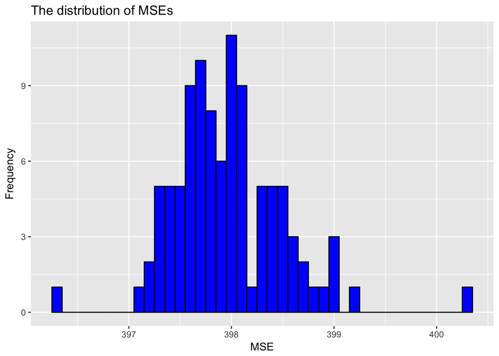

```
##          term     estimate std.error  statistic      p.value
## 1 (Intercept)  58.81125899 3.1244366  18.822996 2.694143e-72
## 2         age   0.04825892 0.0282474   1.708438 8.772744e-02
## 3      female   4.10323009 0.9482286   4.327258 1.592601e-05
## 4        educ  -0.34533479 0.1947796  -1.772952 7.640571e-02
## 5         dem  15.42425563 1.0680327  14.441745 8.144928e-45
## 6         rep -15.84950614 1.3113624 -12.086290 2.157309e-32
```

```
## # A tibble: 6 × 3
##          term     est.boot    se.boot
##         <chr>        <dbl>      <dbl>
## 1 (Intercept)  58.91337251 2.97814255
## 2         age   0.04770968 0.02883481
## 3         dem  15.43020645 1.10724812
## 4        educ  -0.34950530 0.19214401
## 5      female   4.08800549 0.94879605
## 6         rep -15.87431840 1.44433208
```

## Part 2: College (bivariate)

### 1. Instructional expenditure per student vs. out-of-state Tuition

1.1 No transformation This is a simple linear regression model, estimating the relationship between `Expend`, instructional expenditure per student, and `Outstate`, the out-of-state tuition, without transformation. According to the plot below, the simple linear regression without transforamtion does not fit the data vell, although it seems to have captured a positive relationship.

```
##
## Call:
## lm(formula = Outstate ~ Expend, data = collegeData)
##
## Residuals:
##      Min       1Q   Median       3Q      Max
## -15780.8  -2088.7     57.6   2010.8   7784.5
##
## Coefficients:
##              Estimate Std. Error t value Pr(>|t|)
## (Intercept) 5.434e+03  2.248e+02   24.17   <2e-16 ***
## Expend      5.183e-01  2.047e-02   25.32   <2e-16 ***
## ---
## Signif. codes:  0 '***' 0.001 '**' 0.01 '*' 0.05 '.' 0.1 ' ' 1
##
## Residual standard error: 2978 on 775 degrees of freedom
## Multiple R-squared:  0.4526, Adjusted R-squared:  0.4519
## F-statistic: 640.9 on 1 and 775 DF,  p-value: < 2.2e-16
```

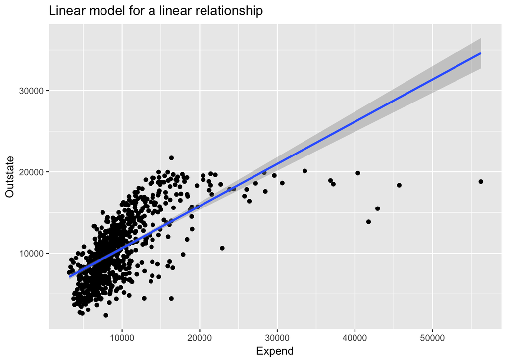

The plot below shows the histogram of residuals. If the linear assumption holds true, the distribution of residuals should have been normally distributed. However, the distribution shown below is not strictly normal.

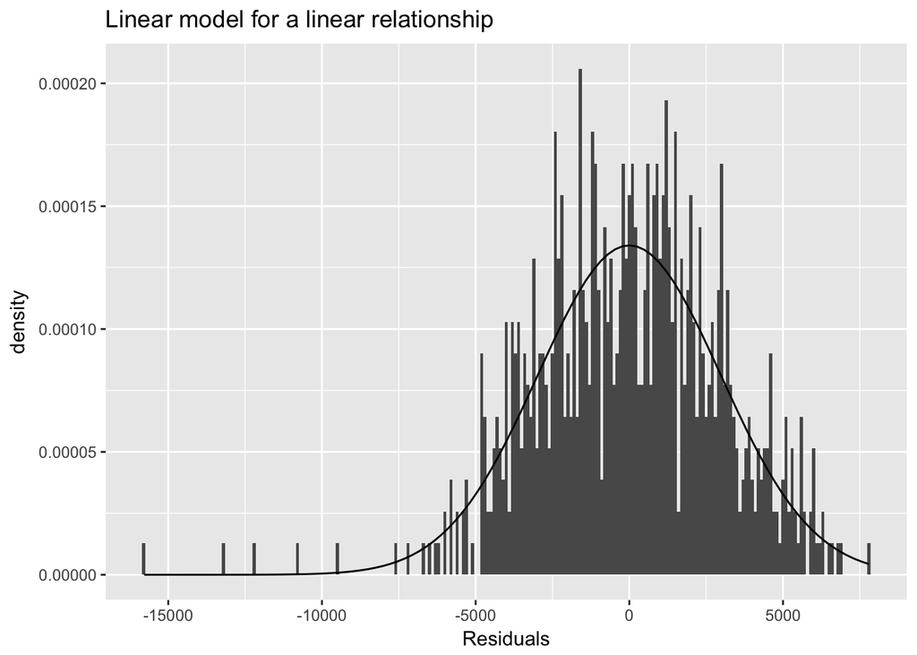

The residuals are not randomly distributed around the predicted values. They are correlated with fitted values, which again violate the linear assumption of OLS.

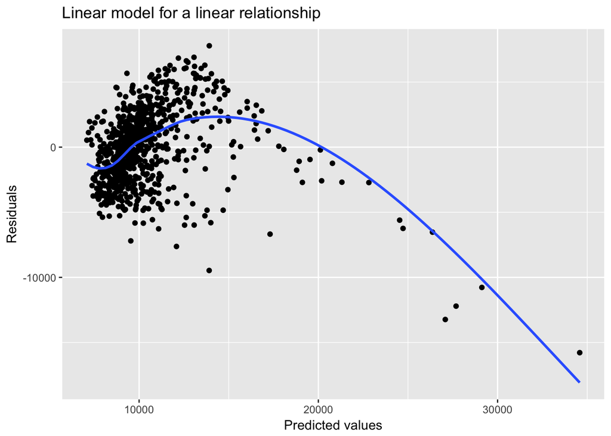

1.2 Polynomial regression This model has the same predictor and response as the previous model, but it applies the polynomial regression approach. According to the results of the model, the parameters for each one of linear, quadratic and cubic terms are statistically significant on the 0.001 significance level. With a better use of information, this model provides a better estimation, compared to the previous model without transformation. And the parameter of the intercept becomes smaller and less statistically significant, which means some unexplained variance in the non-transformation model has been explained by this polynomial regression model.

```
##
## Call:
## glm(formula = Outstate ~ I(Expend^1) + I(Expend^2) + I(Expend^3),
##     data = collegeData)
##
## Deviance Residuals:
##      Min        1Q    Median        3Q       Max
## -11428.4   -1513.1     199.9    1722.1    5932.1
##
## Coefficients:
##               Estimate Std. Error t value Pr(>|t|)
## (Intercept) -1.242e+03  5.605e+02  -2.215    0.027 *
## I(Expend^1)  1.698e+00  1.091e-01  15.570  < 2e-16 ***
## I(Expend^2) -4.632e-05  5.759e-06  -8.043 3.30e-15 ***
## I(Expend^3)  3.950e-10  8.037e-11   4.915 1.08e-06 ***
## ---
## Signif. codes:  0 '***' 0.001 '**' 0.01 '*' 0.05 '.' 0.1 ' ' 1
##
## (Dispersion parameter for gaussian family taken to be 6450537)
##
##     Null deviance: 1.2559e+10  on 776  degrees of freedom
## Residual deviance: 4.9863e+09  on 773  degrees of freedom
## AIC: 14394
##
## Number of Fisher Scoring iterations: 2
```

According to the plot below, this approach fits the data well. Compared to the non-transformation model, more data points are fitted by this model and captured by the 95% confidence interval. This again justify the polynomial regression approach.

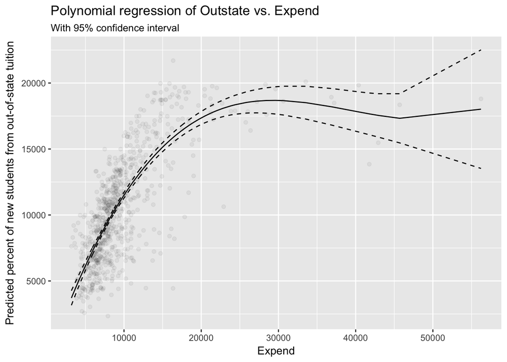

Variance-covariance matrix of Outstate vs. Expend polynomial regression

|  | (Intercept) | I(Expend^1) | I(Expend^2) | I(Expend^3) |
| --- | --- | --- | --- | --- |
| (Intercept) | 314148.81206 | -59.10184 | 0.00285 | 0 |
| I(Expend^1) | -59.10184 | 0.01190 | 0.00000 | 0 |
| I(Expend^2) | 0.00285 | 0.00000 | 0.00000 | 0 |
| I(Expend^3) | 0.00000 | 0.00000 | 0.00000 | 0 |

### 2. Percent of faculty with Ph.D.’s vs. out-of-state tuition

2.2 No transformation First, we use a non-transformation linear model to see how it fits. Although the parameter for `PhD` is statistically significant on the 0.001 level, the plot shows that the relationship is not perfectly captured by the simple linear regression line and its 95% confidence interval.

```
##
## Call:
## lm(formula = Outstate ~ PhD, data = collegeData)
##
## Residuals:
##     Min      1Q  Median      3Q     Max
## -8443.6 -3191.9   179.3  2554.0 14813.0
##
## Coefficients:
##             Estimate Std. Error t value Pr(>|t|)
## (Intercept) 3584.361    608.838   5.887 5.85e-09 ***
## PhD           94.361      8.176  11.542  < 2e-16 ***
## ---
## Signif. codes:  0 '***' 0.001 '**' 0.01 '*' 0.05 '.' 0.1 ' ' 1
##
## Residual standard error: 3719 on 775 degrees of freedom
## Multiple R-squared:  0.1467, Adjusted R-squared:  0.1456
## F-statistic: 133.2 on 1 and 775 DF,  p-value: < 2.2e-16
```

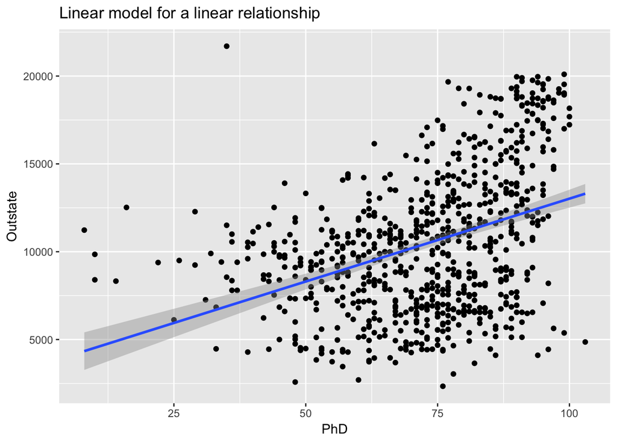

Again, the residuals are not strictly normally distributed.

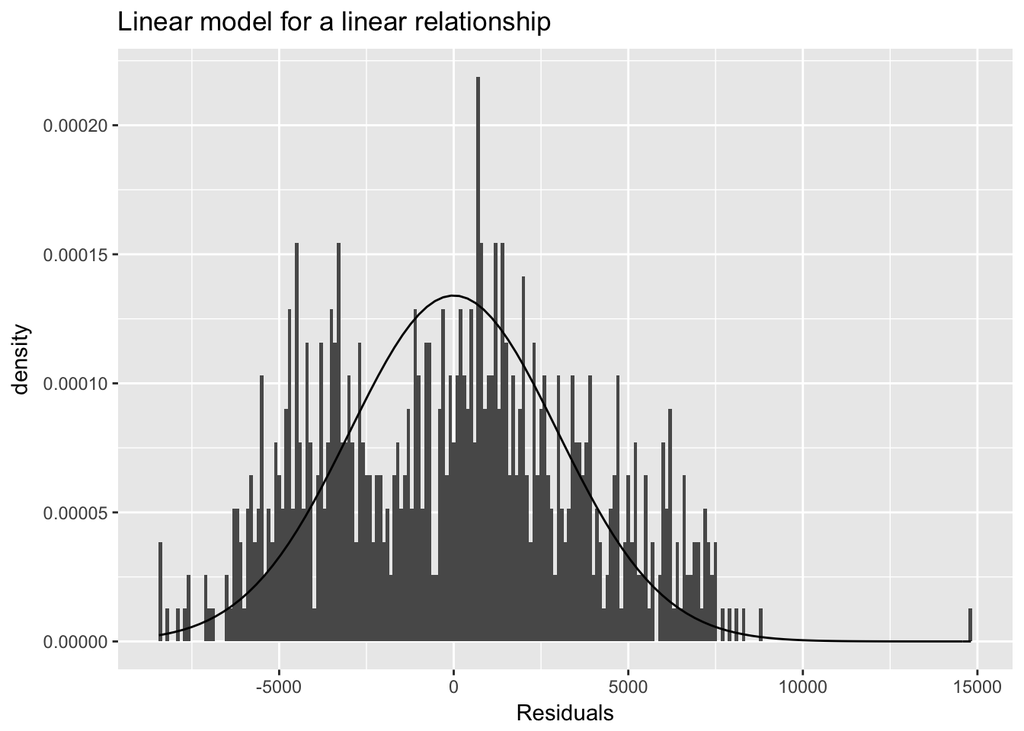

The residuals are not randomly distributed. On the contrary, they are correlated with the fitted values, which is against the linear assumption. I need to use non=linear fitting techniques to solve this problem.

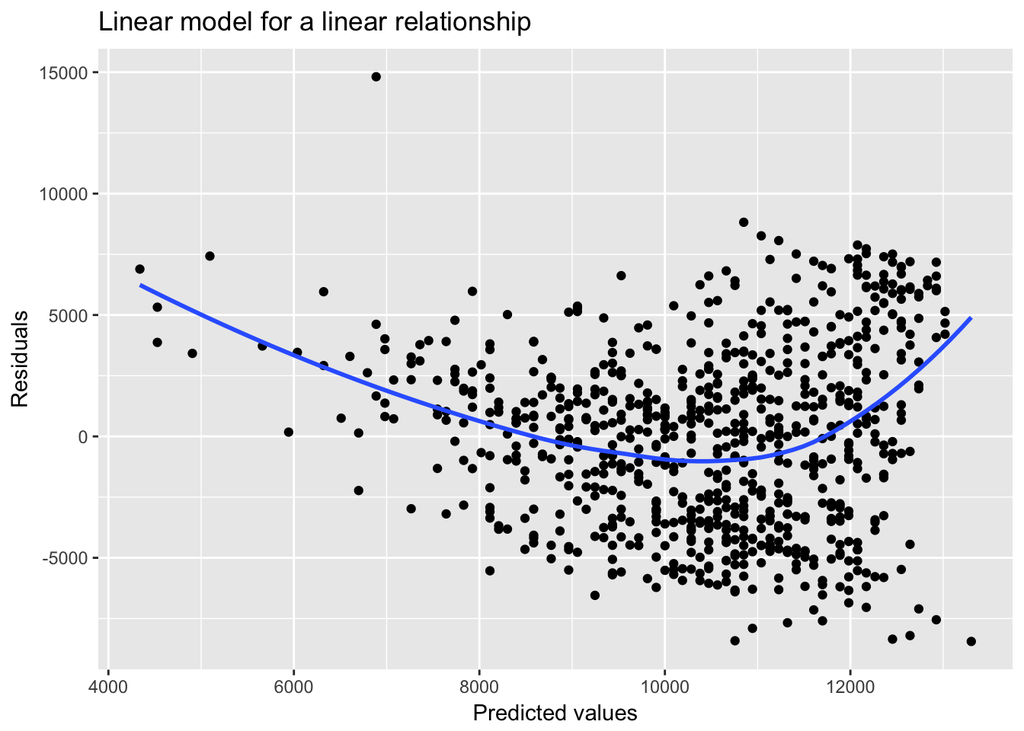

```
##
## Call:
## glm(formula = Outstate ~ bs(PhD, df = 3), data = collegeData)
##
## Deviance Residuals:
##    Min      1Q  Median      3Q     Max
## -13235   -2711     201    2478   12353
##
## Coefficients:
##                  Estimate Std. Error t value Pr(>|t|)
## (Intercept)          9527       1689   5.640 2.38e-08 ***
## bs(PhD, df = 3)1     2073       3284   0.631    0.528
## bs(PhD, df = 3)2    -7394       1570  -4.711 2.93e-06 ***
## bs(PhD, df = 3)3     8568       2006   4.270 2.20e-05 ***
## ---
## Signif. codes:  0 '***' 0.001 '**' 0.01 '*' 0.05 '.' 0.1 ' ' 1
##
## (Dispersion parameter for gaussian family taken to be 12444173)
##
##     Null deviance: 1.2559e+10  on 776  degrees of freedom
## Residual deviance: 9.6193e+09  on 773  degrees of freedom
## AIC: 14905
##
## Number of Fisher Scoring iterations: 2
```

The plot below also shows that the regression splines technique is a better approach for this model, compared to the simple linear regression with no transformation.

[figure not shown]

### 3. Room and board costs vs. out-of-state tuition

3.1 No transformation Similar to the previous step, we first build a model using linear regression without transformation. Although the parameter for `Room.Board` is statistically significant on the 0.001 level, the plot shows that there are too many data points that are not captured by the regression line and its 95% confidence interval, especially at the very left hand side and the very right hand side.

```
##
## Call:
## lm(formula = Outstate ~ Room.Board, data = collegeData)
##
## Residuals:
##     Min      1Q  Median      3Q     Max
## -8781.0 -2070.6  -350.8  1877.4 11877.4
##
## Coefficients:
##              Estimate Std. Error t value Pr(>|t|)
## (Intercept) -17.44525  447.76786  -0.039    0.969
## Room.Board    2.40001    0.09965  24.084   <2e-16 ***
## ---
## Signif. codes:  0 '***' 0.001 '**' 0.01 '*' 0.05 '.' 0.1 ' ' 1
##
## Residual standard error: 3044 on 775 degrees of freedom
## Multiple R-squared:  0.4281, Adjusted R-squared:  0.4273
## F-statistic:   580 on 1 and 775 DF,  p-value: < 2.2e-16
```

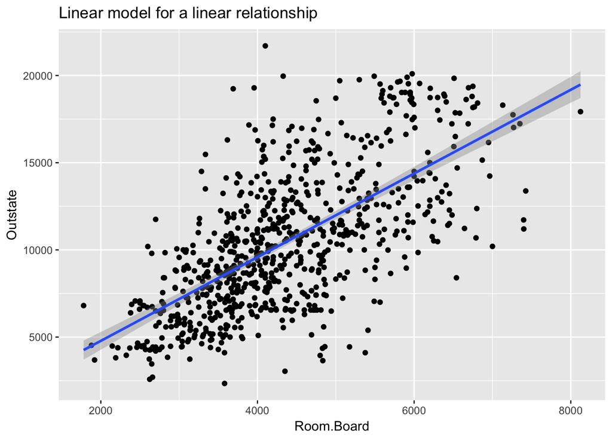

Again, the distribution of residuals are not strictly normal.

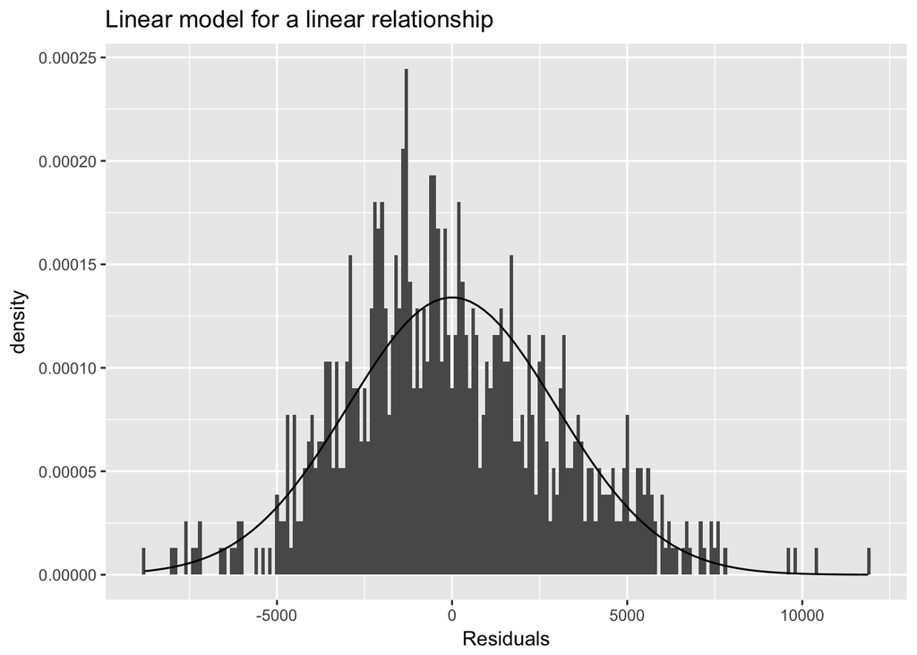

Again, the residuals are somehow correlated with the fitted value.

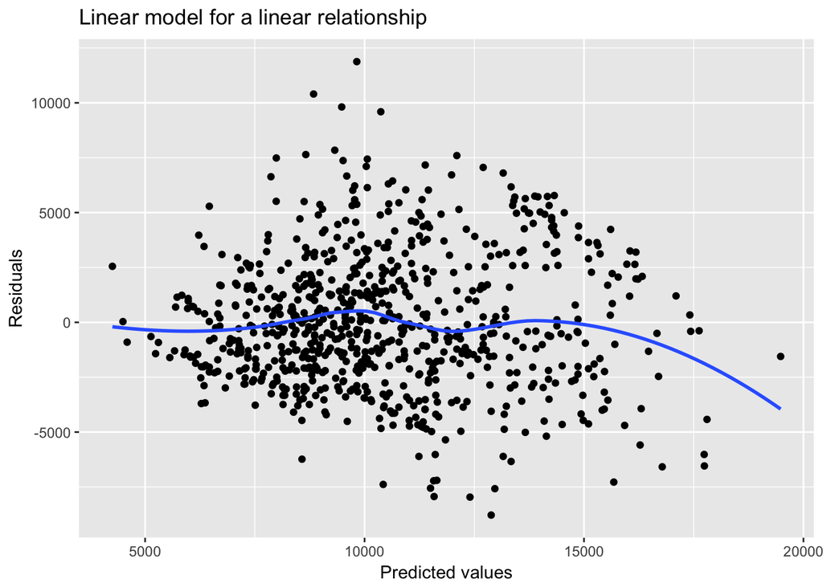

We should again use the regression splines technique for this model, since the first plot shows there is a combination of non-linear trend and local characteristics.

```
##
## Call:
## glm(formula = Outstate ~ bs(Room.Board, df = 4), data = collegeData)
##
## Deviance Residuals:
##     Min       1Q   Median       3Q      Max
## -8996.4  -2036.7   -329.5   1898.4  11800.6
##
## Coefficients:
##                         Estimate Std. Error t value Pr(>|t|)
## (Intercept)                 3448       1397   2.468   0.0138 *
## bs(Room.Board, df = 4)1     2584       1937   1.334   0.1825
## bs(Room.Board, df = 4)2     7936       1274   6.227 7.82e-10 ***
## bs(Room.Board, df = 4)3    13574       2113   6.424 2.31e-10 ***
## bs(Room.Board, df = 4)4    12579       2186   5.755 1.25e-08 ***
## ---
## Signif. codes:  0 '***' 0.001 '**' 0.01 '*' 0.05 '.' 0.1 ' ' 1
##
## (Dispersion parameter for gaussian family taken to be 9236531)
##
##     Null deviance: 1.2559e+10  on 776  degrees of freedom
## Residual deviance: 7.1306e+09  on 772  degrees of freedom
## AIC: 14674
##
## Number of Fisher Scoring iterations: 2
```

The plot shows that this model does a better job in capturing the relationship than the non-transformation model, espcially at the upper end when `Room.Board` gets above 7,000.

[figure not shown]

## Part 3: College (GAM)

```
##
## Call:
## lm(formula = Outstate ~ Private + Room.Board + PhD + perc.alumni +
##     Expend + Grad.Rate, data = college_split$train)
##
## Residuals:
##     Min      1Q  Median      3Q     Max
## -7755.7 -1325.5  -112.8  1300.0 10537.0
##
## Coefficients:
##               Estimate Std. Error t value Pr(>|t|)
## (Intercept) -3595.7775   538.4138  -6.678 6.04e-11 ***
## PrivateYes   2575.4372   253.9221  10.143  < 2e-16 ***
## Room.Board      0.9927     0.1028   9.661  < 2e-16 ***
## PhD            36.5287     6.8007   5.371 1.17e-07 ***
## perc.alumni    53.3855     9.0482   5.900 6.43e-09 ***
## Expend          0.2067     0.0207   9.987  < 2e-16 ***
## Grad.Rate      30.7296     6.6964   4.589 5.55e-06 ***
## ---
## Signif. codes:  0 '***' 0.001 '**' 0.01 '*' 0.05 '.' 0.1 ' ' 1
##
## Residual standard error: 2090 on 537 degrees of freedom
## Multiple R-squared:  0.7263, Adjusted R-squared:  0.7232
## F-statistic: 237.5 on 6 and 537 DF,  p-value: < 2.2e-16
```

```
## [1] 4310543
```

```
## [1] 3595260
```

3. The table below shows the results of the GAM model. I use the local regression fitting technique for this part, since there may be localized relationships between the predictors and the response.

```
##
## Call: gam(formula = Outstate ~ Private + lo(Room.Board) + lo(PhD) +
##     lo(perc.alumni) + lo(Expend) + lo(Grad.Rate), data = college_split$train)
## Deviance Residuals:
##       Min        1Q    Median        3Q       Max
## -6869.766 -1075.222    -7.725  1306.604  7350.476
##
## (Dispersion Parameter for gaussian family taken to be 3505820)
##
##     Null Deviance: 8567705097 on 543 degrees of freedom
## Residual Deviance: 1830999221 on 522.2741 degrees of freedom
## AIC: 9765.13
##
## Number of Local Scoring Iterations: 2
##
## Anova for Parametric Effects
##                     Df     Sum Sq    Mean Sq F value    Pr(>F)
## Private           1.00 2077387072 2077387072 592.554 < 2.2e-16 ***
## lo(Room.Board)    1.00 1615921216 1615921216 460.925 < 2.2e-16 ***
## lo(PhD)           1.00  569571637  569571637 162.465 < 2.2e-16 ***
## lo(perc.alumni)   1.00  340298155  340298155  97.067 < 2.2e-16 ***
## lo(Expend)        1.00  787646975  787646975 224.668 < 2.2e-16 ***
## lo(Grad.Rate)     1.00   90946311   90946311  25.942 4.923e-07 ***
## Residuals       522.27 1830999221    3505820
## ---
## Signif. codes:  0 '***' 0.001 '**' 0.01 '*' 0.05 '.' 0.1 ' ' 1
##
## Anova for Nonparametric Effects
##                 Npar Df  Npar F   Pr(F)
## (Intercept)
## Private
## lo(Room.Board)      3.0  2.8779 0.03592 *
## lo(PhD)             2.7  2.5941 0.05826 .
## lo(perc.alumni)     2.4  1.7847 0.16024
## lo(Expend)          4.0 28.2697 < 2e-16 ***
## lo(Grad.Rate)       2.6  3.1279 0.03177 *
## ---
## Signif. codes:  0 '***' 0.001 '**' 0.01 '*' 0.05 '.' 0.1 ' ' 1
```

The plots below show the relationships between each of the predictors and the response `Outstate`. According to the plot below, there is a positive relationship between `Room.Board` and `Outstate`. When the room and board costs increase, the out-of-state tuition also increases. But before the room and board costs reach 4,000, the slop is increasing when tthe costs are increasing. After it reach 4,000, the slop gets stable.

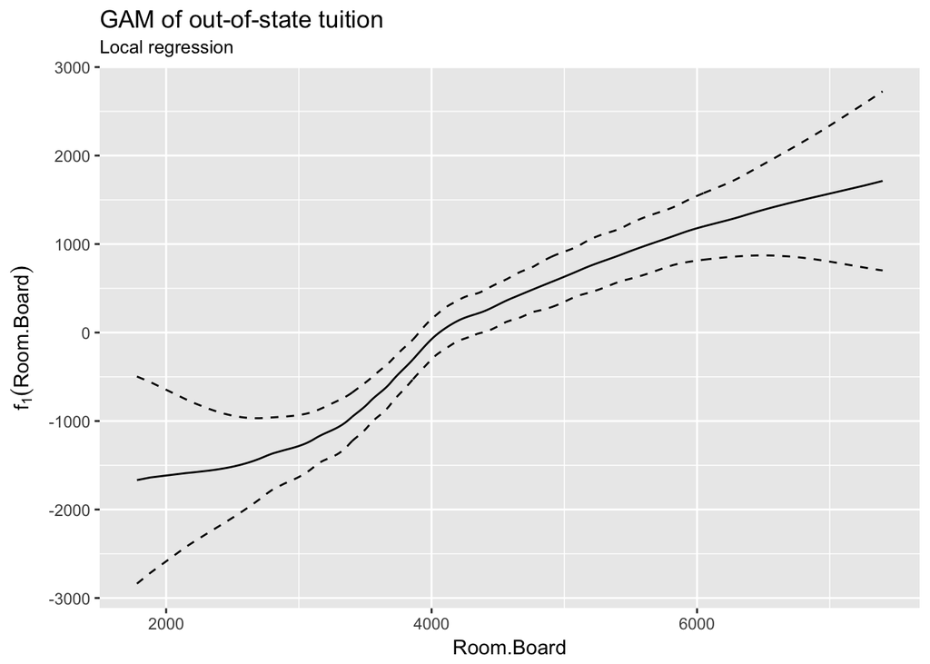

```r
# get graphs of each term
problem3_gam_terms <- preplot(problem3_gam, se = TRUE, rug = FALSE)

## Room.Board
data_frame(x = problem3_gam_terms$`lo(Room.Board)`$x,
           y = problem3_gam_terms$`lo(Room.Board)`$y,
           se.fit = problem3_gam_terms$`lo(Room.Board)`$se.y) %>%
  mutate(y_low = y - 1.96 * se.fit,
         y_high = y + 1.96 * se.fit) %>%
  ggplot(aes(x, y)) +
  geom_line() +
  geom_line(aes(y = y_low), linetype = 2) +
  geom_line(aes(y = y_high), linetype = 2) +
  labs(title = "GAM of out-of-state tuition",
       subtitle = "Local regression",
       x = "Room.Board",
       y = expression(f[1](Room.Board)))
```

According to the plot below, we could see a generally positive relationship between `PhD` and `Outstate`. However, when the percent of falculty with Ph.D.’s is approximately between 30 and 50, the relationship is negative. But this does not influence the overall positive trend.

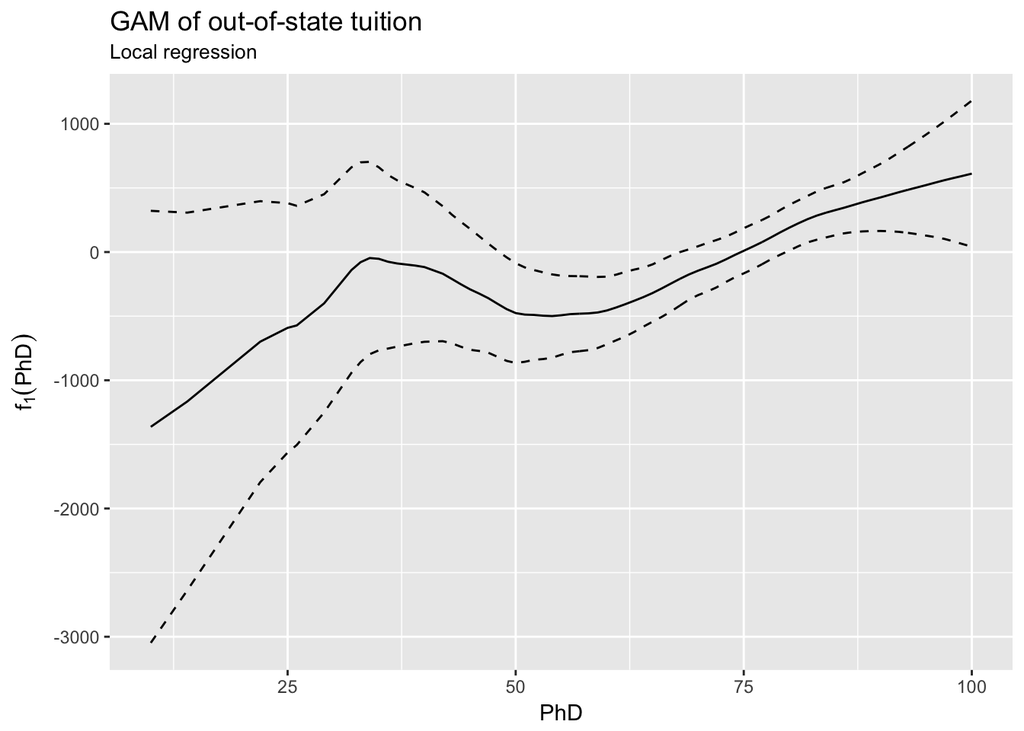

```r
## PhD
data_frame(x = problem3_gam_terms$`lo(PhD)`$x,
           y = problem3_gam_terms$`lo(PhD)`$y,
           se.fit = problem3_gam_terms$`lo(PhD)`$se.y) %>%
  mutate(y_low = y - 1.96 * se.fit,
         y_high = y + 1.96 * se.fit) %>%
  ggplot(aes(x, y)) +
  geom_line() +
  geom_line(aes(y = y_low), linetype = 2) +
  geom_line(aes(y = y_high), linetype = 2) +
  labs(title = "GAM of out-of-state tuition",
       subtitle = "Local regression",
       x = "PhD",
       y = expression(f[1](PhD)))
```

According to the plot below, we could see a positive relationship between `perc.alumni` and `Outstate`. The out-of-state tuition gets increased with the increase of percent of alumni who donate.

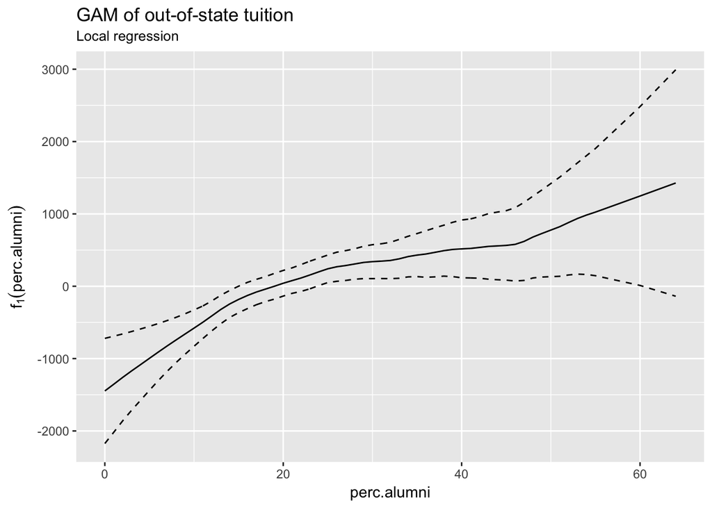

```r
## perc.alumni
data_frame(x = problem3_gam_terms$`lo(perc.alumni)`$x,
           y = problem3_gam_terms$`lo(perc.alumni)`$y,
           se.fit = problem3_gam_terms$`lo(perc.alumni)`$se.y) %>%
  mutate(y_low = y - 1.96 * se.fit,
         y_high = y + 1.96 * se.fit) %>%
  ggplot(aes(x, y)) +
  geom_line() +
  geom_line(aes(y = y_low), linetype = 2) +
  geom_line(aes(y = y_high), linetype = 2) +
  labs(title = "GAM of out-of-state tuition",
       subtitle = "Local regression",
       x = "perc.alumni",
       y = expression(f[1](perc.alumni)))
```

With `Expend`, we could see that the relationship between `Expend` and `Outstate` is more complex than an OLS relationship. Before `Expend` gets to 30,000, the out-of-state tuition is increased with the increase of instructional expenditure per student. But when `Expend` gets larger than 30,000, the out-of-state tuition gets decreased with the increase of instructional expenditure per student.

[figure not shown]

```r
## Expend
data_frame(x = problem3_gam_terms$`lo(Expend)`$x,
           y = problem3_gam_terms$`lo(Expend)`$y,
           se.fit = problem3_gam_terms$`lo(Expend)`$se.y) %>%
  mutate(y_low = y - 1.96 * se.fit,
         y_high = y + 1.96 * se.fit) %>%
  ggplot(aes(x, y)) +
  geom_line() +
  geom_line(aes(y = y_low), linetype = 2) +
  geom_line(aes(y = y_high), linetype = 2) +
  labs(title = "GAM of out-of-state tuition",
       subtitle = "Local regression",
       x = "perc.alumni",
       y = expression(f[1](Expend)))
```

With `Grad.Rate`, we could see that the relationship between `Grad.Rate` and `Outstate` is more complex than an OLS relationship. Before `Grad.Rate` gets to 80, the out-of-state tuition is increased with the increase of graduation rate. But when `Grad.Rate` gets larger than 80, the out-of-state tuition gets decreased with the increase of graduation rate.

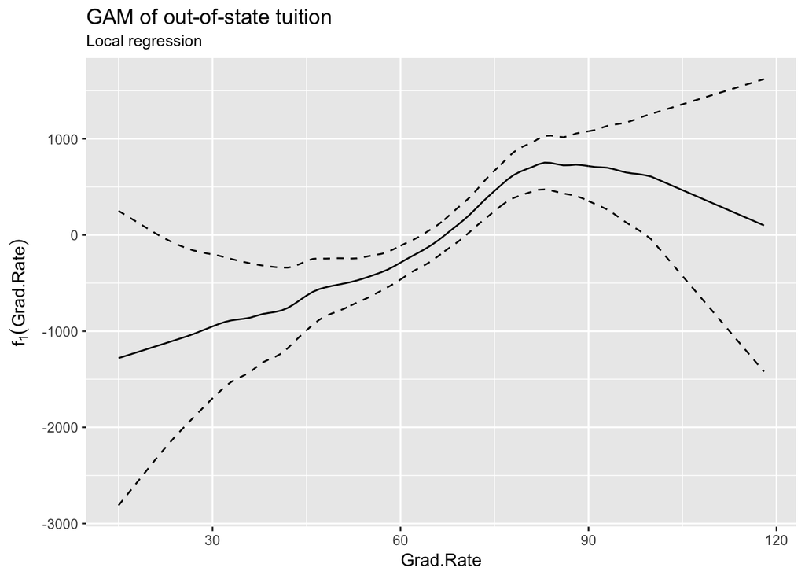

```r
## Grad.Rate
data_frame(x = problem3_gam_terms$`lo(Grad.Rate)`$x,
           y = problem3_gam_terms$`lo(Grad.Rate)`$y,
           se.fit = problem3_gam_terms$`lo(Grad.Rate)`$se.y) %>%
  mutate(y_low = y - 1.96 * se.fit,
         y_high = y + 1.96 * se.fit) %>%
  ggplot(aes(x, y)) +
  geom_line() +
  geom_line(aes(y = y_low), linetype = 2) +
  geom_line(aes(y = y_high), linetype = 2) +
  labs(title = "GAM of out-of-state tuition",
       subtitle = "Local regression",
       x = "Grad.Rate",
       y = expression(f[1](Grad.Rate)))
```

With the plot for `Private`, we could see that being a private university has a substantially positive effect on out-of-state tuition.

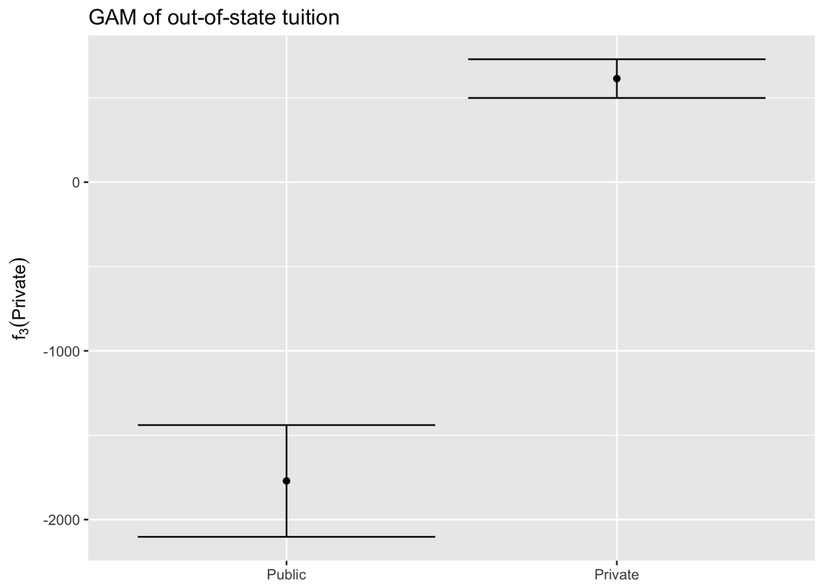

4. The test MSE for OLS model and the test MSE for GAM model are shown as below. We could see that the GAM model produces less errors than the OLS model.

```
## [1] 3595260
```

```
## [1] 3365807
```

5. According to the plots in part(3), `Expend` and `Grad.Rate` seem to have long-linear relationship with the response. For `Expend`, approximately below 30,000, the relationship between `Expend` and `Outstate` is positive. But approximately above 30,000, the relationship between `Expend` and `Outstate` is getting negative. This would not be a linear relationship. For `Grad.Rate`, it is similar. Approximately below 80, the relationship between `Grad.Rate` and `Outstate` is positive, but approximately above 80, the relationship between `Grad.Rate` and `Outstate` is negative. This would not be a linear relationship.